# Index

## Introduction

This documents accompain the R code used in the **Practical session #2** - *Mapping deep-water fishing grounds: from fishing tracks to fishing effort maps*. It aims to detail part of the workflow adopted to elaborate Automatic Identification System (AIS) data in the context of the GFCM initiative to map fishing ground for deep-water red shrimp in the Eastern-Central Mediterranean Sea. The focus is on some of the plots shown in the chapter 3.4 of the report, in particular those referring to the aggregated fishing effort (Figure 1 a and b) and to the DCF indicators of fishing pressure (Figure 1 c and d).

## Structure

This document is structured into three sections that will be approached within the lesson:

- *Processing and analysis*: here is presented the entire workflow that would be shown during the lecture. Starting from fishing tracks, data are intersected with a spatial grid. The results are aggregated in different ways to produce fishing effort metrics and indicators.
- *Functions*: contains the customized functions used repeatedly within the code.
- *Exercise*: this section contains the instructions needed to complete the lecture exercise.

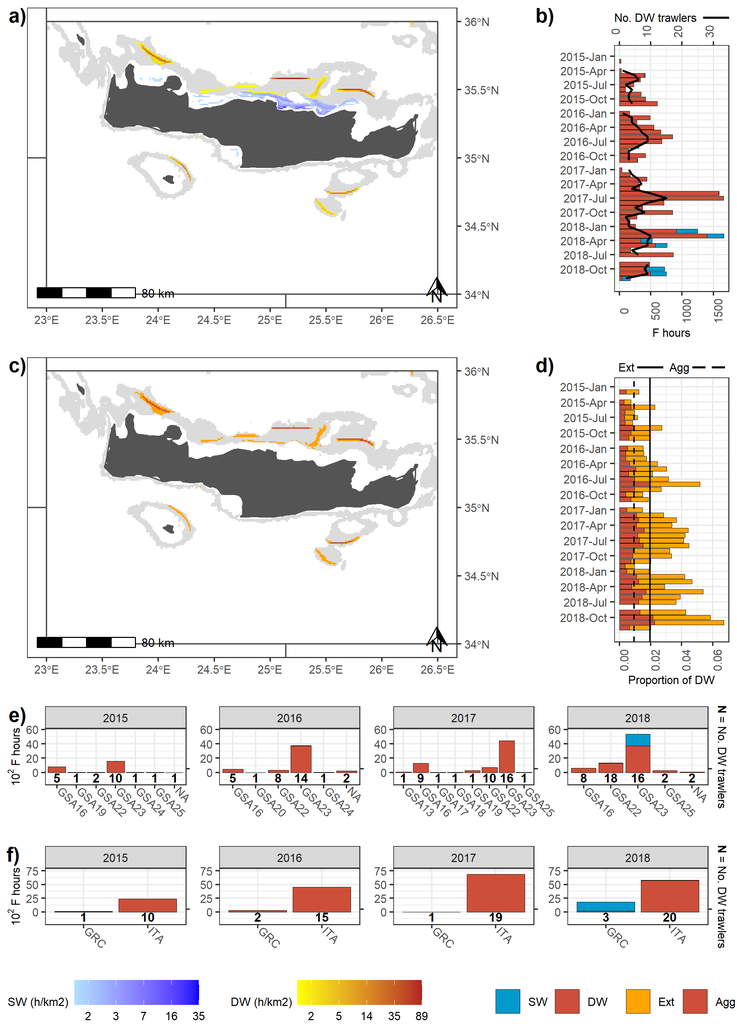

Figure 1: Fishing activities of vessels DW trawling in GSA 23. (a) Spatial distribution of mean DW and SW fishing activities during the study period; (b) Monthly fishing hours in DW (red) and SW (blue), and number of DW trawlers exerting these activities (solid line); (c) Spatial distribution of fishing pressure indicators of Extension (orange) and Aggregation (red) during the study period; (d) Monthly proportions of the DW area trawled and average values for fishing pressure indicators of extension (orange bars and solid line, respectively) and aggregation (red bars and dashed line, respectively); (e - f) Annual fishing hours in DW (red) and SW (blue) by GSA of arrival and country, and number of DW trawlers exerting these activities